# Milestone Report: Exploratory Data Analisys

Nikunj Rathod

April 18, 2020

We will use a huge amount of data that provided by [HC Corpora](http://www.corpora.heliohost.org/). It will be used to train our app to predict next word in the text that user types. The data was collected by **HC Corpora** and recompiled for **Coursera** students by **Swiftkey** team. This package contains sets of News, Blog Posts and Tweets with 4 languages - English, Deutch, Finnish and Russian. I will use English texts for our learning purposes.

Before we start let’s ensure we have the data and load it. I will use speacially prepared utils to load it into varaibles with names *twitter.lines*, *blogs.lines* and *news.lines*.

```r
source('utils/requirements.R')
source('utils/data.R')
prepare_data()
```

Function *prepare_data()* will ensure that **Coursera-SwiftKey.zip** is downloaded and that necessery files are unzipped into *data* folder.

## Examine files

I will check the line qty and it’s statistical properties for every file. I will also try to find more interesting facts about the data.

Let’s start from file sizes and the qty if line for every file.

```r
get_file_by_name = function(name){
    paste(c('en_US', name, 'txt'), collapse = ".")
}

get_file_path_by_name = function(name){
    file_name = get_file_by_name(name)
    file_path = paste(c(data_folder_name, file_name), collapse = "/")
}

get_data = function(name){
    file_path = get_file_path_by_name(name)
    scan(file_path, what = "character", sep = "\n")
}

# Sample size is 25%
sample_size = 0.25

twitter.lines <- get_data('twitter')
twitter.lines.lengths = nchar(twitter.lines)
twitter.lines.summary = summary(twitter.lines.lengths)
twitter.lines.sample = twitter.lines[
    sample(
        1:length(twitter.lines),
        round(length(twitter.lines) * sample_size)
    )
]
rm(twitter.lines)

blogs.lines <- get_data('blogs')
blogs.lines.lengths = nchar(blogs.lines)
blogs.lines.summary = summary(blogs.lines.lengths)
blogs.lines.sample = blogs.lines[
    sample(
        1:length(blogs.lines),
        round(length(blogs.lines) * sample_size)
    )
]
rm(blogs.lines)

news.lines <- get_data('news')
news.lines.lengths = nchar(news.lines)
news.lines.summary = summary(news.lines.lengths)
news.lines.sample = news.lines[
    sample(
        1:length(news.lines),
        round(length(news.lines) * sample_size)
    )
]
rm(news.lines)

get_file_size_in_mb = function(name){
    file_path = get_file_path_by_name(name)
    file_info = file.info(file_path)
    file_info$size / 1024.0 / 1024.0
}

get_line_qty = function(variable){
    length(variable)
}

row.names = c('Tweets', 'Blog Posts', 'News Records')
row.file_names = c(get_file_by_name('twitter'), get_file_by_name('blogs'), get_file_by_name('news'))
row.file_sizes = c(get_file_size_in_mb('twitter'), get_file_size_in_mb('blogs'), get_file_size_in_mb('news'))
row.line_qtys = c(
    get_line_qty(twitter.lines.lengths),
    get_line_qty(blogs.lines.lengths),
    get_line_qty(news.lines.lengths)
)

row.min_lines = c(twitter.lines.summary[1], blogs.lines.summary[1], news.lines.summary[1])
row.max_lines = c(twitter.lines.summary[6], blogs.lines.summary[6], news.lines.summary[6])
row.mean_lines = c(twitter.lines.summary[4], blogs.lines.summary[4], news.lines.summary[4])
row.median_lines = c(twitter.lines.summary[3], blogs.lines.summary[3], news.lines.summary[3])

summary.table = data.frame(
    row.names,
    row.file_names,
    row.file_sizes,
    row.line_qtys,
    row.min_lines,
    row.max_lines,
    row.mean_lines,
    row.median_lines
)

colnames(summary.table) = c(
    "Data Source",
    "File Name",
    "File Size, Mb",
    "Lines in the file",
    "Min Line Lenght",
    "Max Line Lenght",
    "Avg Line Lenght",
    "Median of Line Lenght"
)
```

We’ve prepared data. So let’s print it.

```r
pander(summary.table, justify = 'left')
```

Table continues below

| Data Source | File Name | File Size, Mb | Lines in the file |
| --- | --- | --- | --- |
| Tweets | en_US.twitter.txt | 159.4 | 2360148 |
| Blog Posts | en_US.blogs.txt | 200.4 | 899288 |
| News Records | en_US.news.txt | 196.3 | 1010242 |

| Min Line Lenght | Max Line Lenght | Avg Line Lenght | Median of Line Lenght |
| --- | --- | --- | --- |
| 2 | 140 | 68.68 | 64 |
| 1 | 40830 | 230 | 156 |
| 1 | 11380 | 201.2 | 185 |

To understand the dencity of the lenghs for each of data source let’s build violin plot. It will show us the real picture about length of lines in the corpus.

```r
twitter.df = data.frame(
    twitter.lines.lengths,
    rep("Twitter", length(twitter.lines.lengths))
)
colnames(twitter.df) = c('length', 'source')

blogs.df = data.frame(
    blogs.lines.lengths,
    rep("Blogs", length(blogs.lines.lengths))
)
colnames(blogs.df) = c('length', 'source')

news.df = data.frame(
    news.lines.lengths,
    rep("News", length(news.lines.lengths))
)
colnames(news.df) = c('length', 'source')

combined.df = rbind(twitter.df, blogs.df, news.df)
```

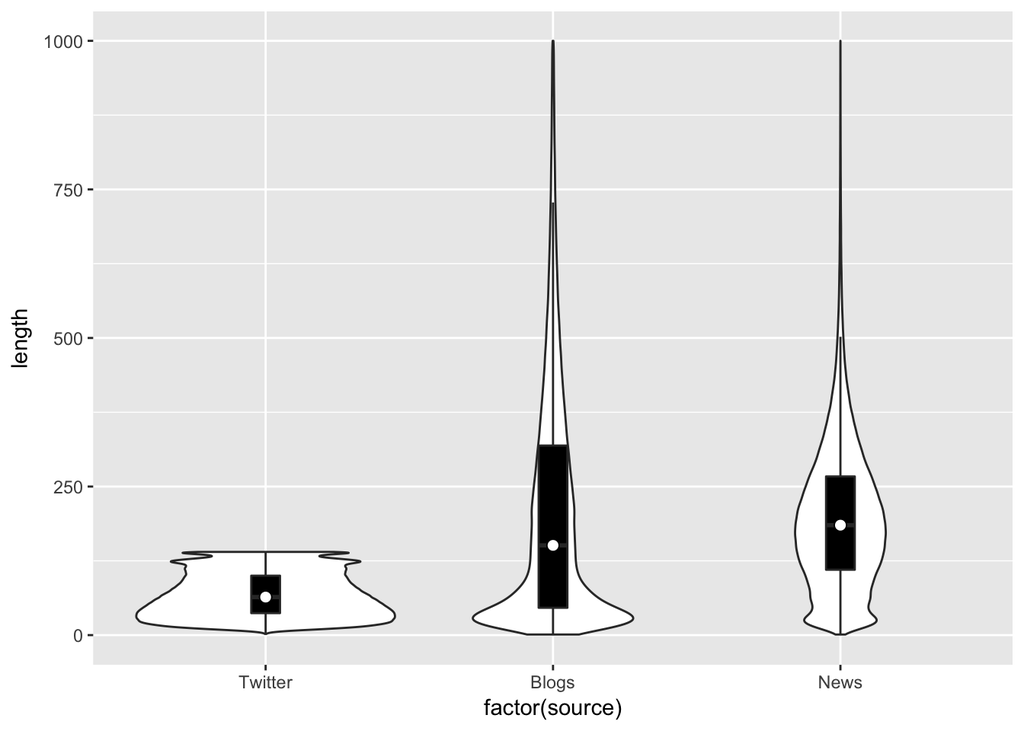

```r
ggplot(combined.df, aes(x=factor(source), y=length)) +
    geom_violin() +
    geom_boxplot(width=.1, fill="black", outlier.colour=NA) +
    stat_summary(fun.y=median, geom="point", fill="white", shape=21, size=2.5) +
    ylim(0, 1000)
```

## Keyword Dencity Analysis

To realize the content of the gived sources I’d like clean it up and tokenize it with n-grams. But as soon as the original data source is huge I need to prepare the sample data set that is smaller. And it’s easier to work with.

### Samplpling the Data

```r
sample.lines  = c(twitter.lines.sample, blogs.lines.sample, news.lines.sample)
rm(twitter.lines.sample)
rm(blogs.lines.sample)
rm(news.lines.sample)
```

Now I have sample data set that contains 1067419 lines with representative data. We can easly process it but in the other hand we can make some suggestions on the basis of that data.

### Clean Up Sample Data Set

I’ve examined some control characters in the corpus. As first step of cleanup process I need to remove them from corpus.

```r
sample.lines <- iconv(sample.lines, to="UTF-8", sub="byte")
```

We need to find per senrtence n-grams. Our main goal is to predict next word of text on per sentence basis. So, the next step is te split lines into sentences.

```r
split_to_sentences = function(lines){
    unlist(lines %>% regexp_tokenizer(pattern = '[\\.\\?\\!]+'))
}

sample.sentences <- split_to_sentences(sample.lines)
rm(sample.lines)
```

### Tockenize Cleaned Sample Corpus

I will tokenize corpus and find n-grams using **text2vec** package. I found is a fastest way to get job done.

```r
# Load stopwords from external dictionary
words_to_remove = c(
    get_profanity_words(),
    tokenizers::stopwords('en')
)

# Prepare tokenizer function
get_tokens = function(sentences){
    tokens = itoken(
        sentences,
        preprocess_function = tolower,
        tokenizer = tokenizers::tokenize_words,
        chunks_number = 10,
        progessbar = TRUE
    )
    tokens
}

# Extract n-grams from tokens vocabluary
prepare_ngrams = function(lines, ngrams_num){
    tokens <- get_tokens(lines)
    min_n_gram <- ngrams_num
    max_n_gram <- ngrams_num
    vocab = create_vocabulary(
        tokens,
        c(min_n_gram, max_n_gram),
        stopwords <- words_to_remove
    )
    vocab <- prune_vocabulary(vocab, term_count_min = 2)
    vocab$vocab
}

get_ngrams <- function(lines, ngram_count, limit = FALSE, remove_underscore = FALSE){
    vocabluary <- prepare_ngrams(lines, ngram_count)
    ngrams <- select(vocabluary, terms, terms_counts) %>% arrange(desc(terms_counts))

    if (limit){
        ngrams <- ngrams[1:limit, ]
    }

    if (remove_underscore){
        ngrams$terms <- gsub("\\_", " ", ngrams$terms)
    }

    colnames(ngrams) <- c("Terms", "Count")
    ngrams
}

unigrams <- get_ngrams(sample.sentences, 1, 50, remove_underscore = TRUE)
bigrams <- get_ngrams(sample.sentences, 2, 50, remove_underscore = TRUE)
trigrams <- get_ngrams(sample.sentences, 3, 50, remove_underscore = TRUE)
```

After we’ve prepared *n-grams* we can plot it on wordcloud. I’d like to use wordcloud because it helps to understand how word dencity looks like.

#### Top 50 Unigrams

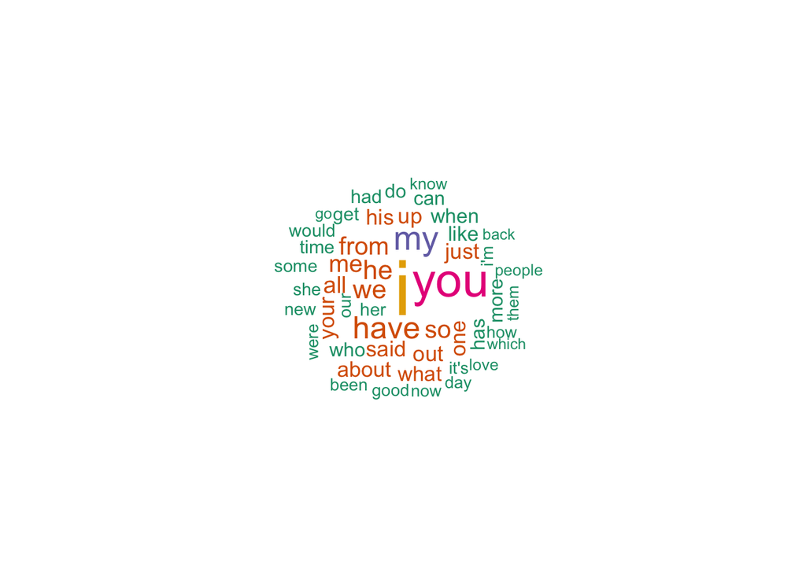

```r
set.seed(12345)
pal <- brewer.pal(6, "Dark2")
wordcloud(
  words = unigrams$Terms,
  freq = unigrams$Count,
  random.order=FALSE,
  use.r.layout=FALSE,
  colors = pal
)
```

#### Top 50 Bigrams

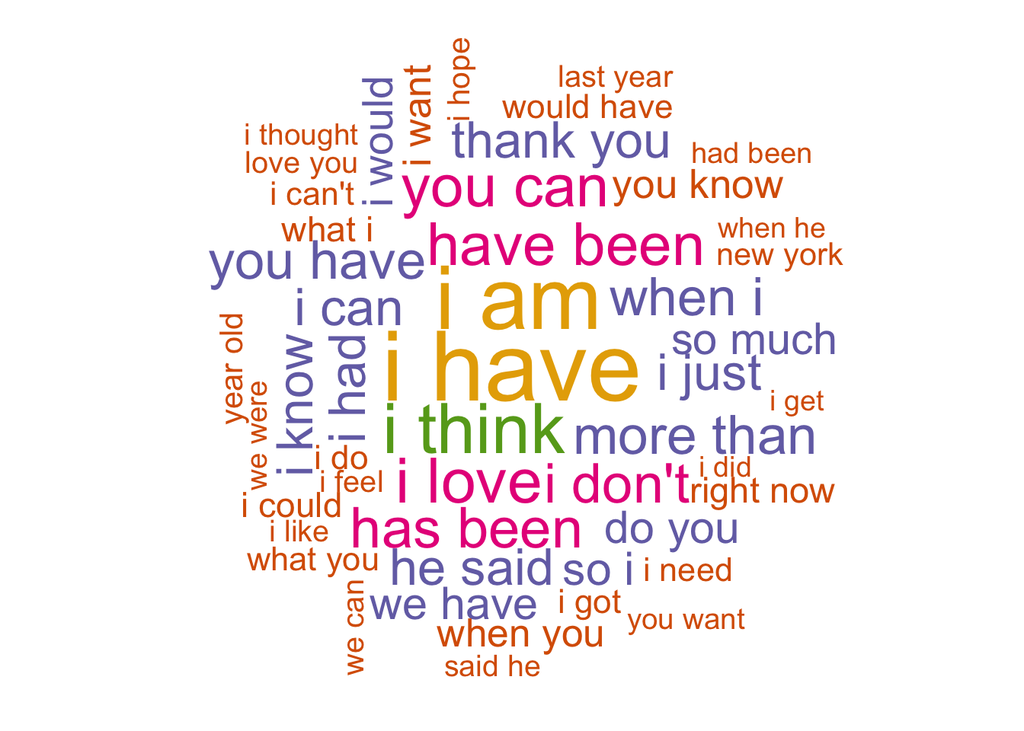

```r
set.seed(12345)
pal <- brewer.pal(6, "Dark2")
wordcloud(
  words = bigrams$Terms,
  freq = bigrams$Count,
  random.order=FALSE,
  use.r.layout=FALSE,
  colors = pal
)
```

#### Top 50 Trigrams

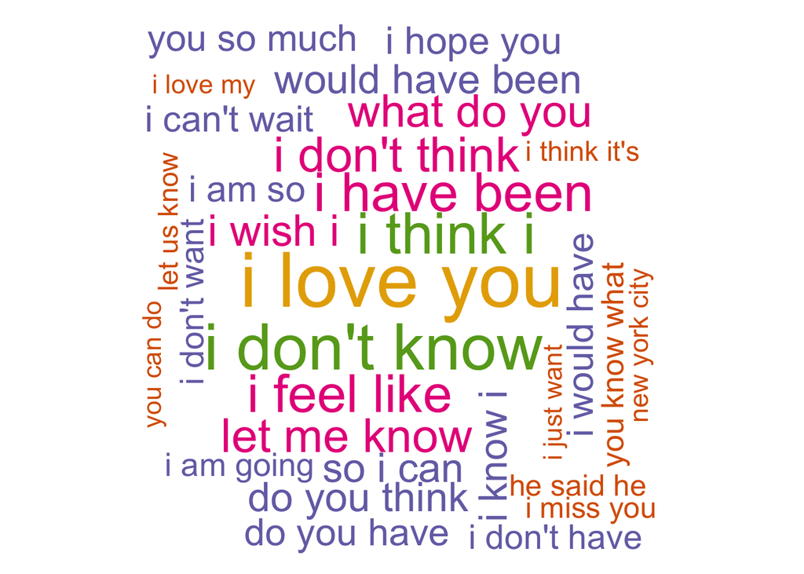

```r
set.seed(12345)
pal <- brewer.pal(6, "Dark2")
wordcloud(
  words = trigrams$Terms,
  freq = trigrams$Count,
  random.order=FALSE,
  use.r.layout=FALSE,
  colors = pal
)
```

Looks great! We can see top 50 of *n-grams* which used in corpus. So we can realize what *n-grams* most recently used in the texts. Sure, we discovered sample only. But in statistical matter the sample completely represents it’s source.

### Conclusions

Also there are some conclustions that can help to make prediction model better.

- There are some abbreviations we should convert into full form on cleaning up stage. For example *I’m* should be converted into *I am* etc. We will have more consistant data due to this.
- I think we shouldn’t remove stop-words according to purposes of this work, because we build prediction model which helps humans to type text. And the stopwords is the important part of the natural language. At least I will try to test prediction models with and without stopwords to test which will works better.